## Connect With Us

- Website (https://www.rsquaredacademy.com/)
- Free Online R Courses (https://rsquared-academy.thinkific.com/)
- R Packages (https://pkgs.rsquaredacademy.com)
- Shiny Apps (https://apps.rsquaredacademy.com)
- Blog (https://blog.rsquaredacademy.com)
- GitHub (https://github.com/rsquaredacademy)
- YouTube (https://www.youtube.com/user/rsquaredin/)
- Twitter (https://twitter.com/rsquaredacademy)
- Facebook (https://www.facebook.com/rsquaredacademy/)
- Linkedin (https://in.linkedin.com/company/rsquared-academy)

## Resources

- [Slides](https://slides.rsquaredacademy.com/rfm/rfm.html)
- [Blog Post](https://blog.rsquaredacademy.com/customer-segmentation-using-rfm-analysis/)
- [Code & Data](https://github.com/rsquaredacademy-education/online-courses/tree/master/customer-segmentation-using-rfm-analysis/script)
- [RStudio Cloud](https://rstudio.cloud/project/416146)
- [Shiny App](https://apps.rsquaredacademy.com/)
- [R Package](https://rfm.rsquaredacademy.com/)

## Transaction Data

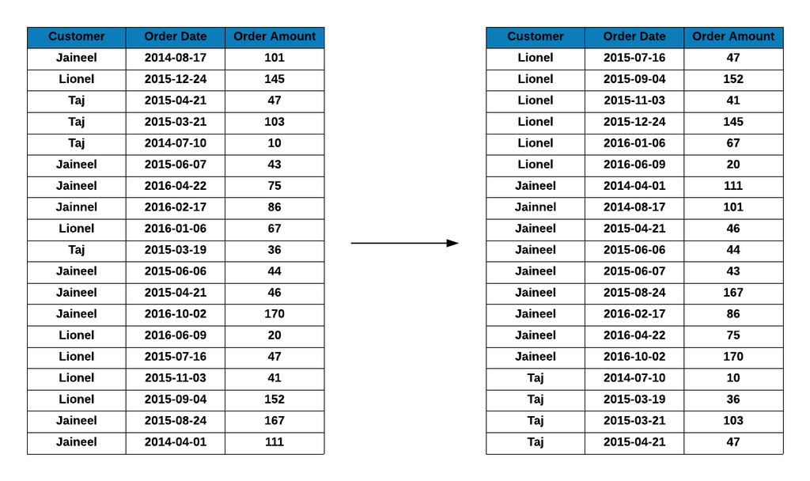

## RFM Table

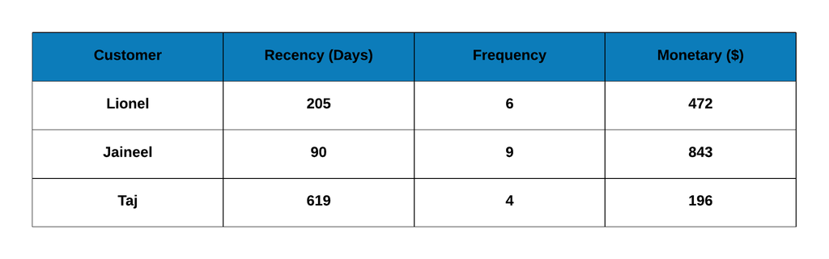

## RFM Score

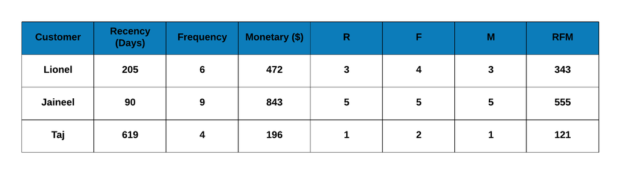

## Segments

[figure not shown]

## Introduction

**RFM** (recency, frequency, monetary) analysis is a behavior based technique used to segment customers by examining their transaction history such as

- how recently a customer has purchased (recency)
- how often they purchase (frequency)
- how much the customer spends (monetary)

It is based on the marketing axiom that **80% of your business comes from 20% of your customers**. RFM helps to identify customers who are more likely to respond to promotions by segmenting them into various categories.

## Applications

[figure not shown]

## RFM Table

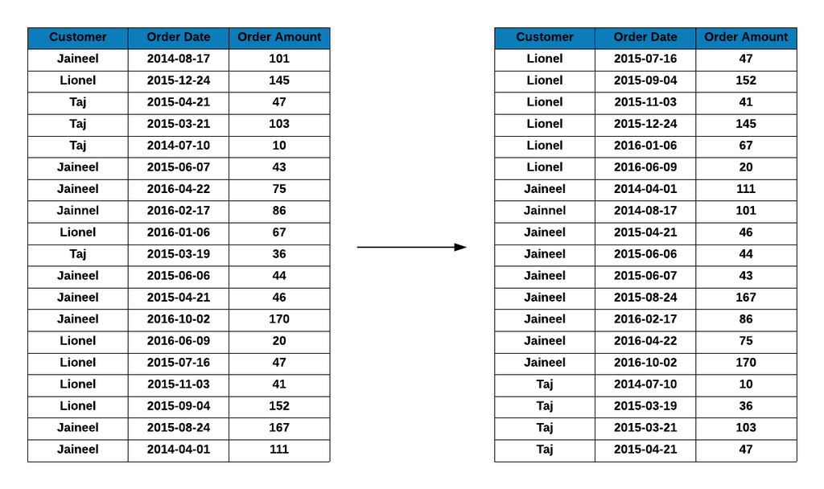

## RFM Table

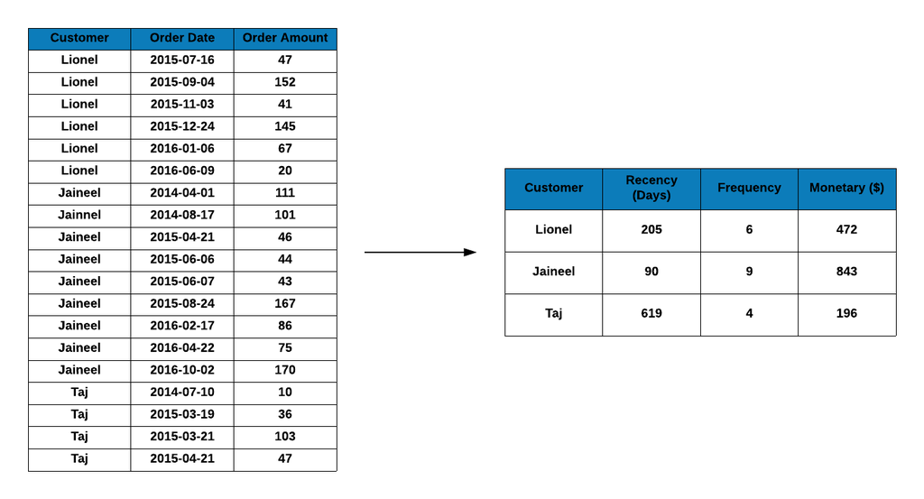

## Metrics

[figure not shown]

## Recency

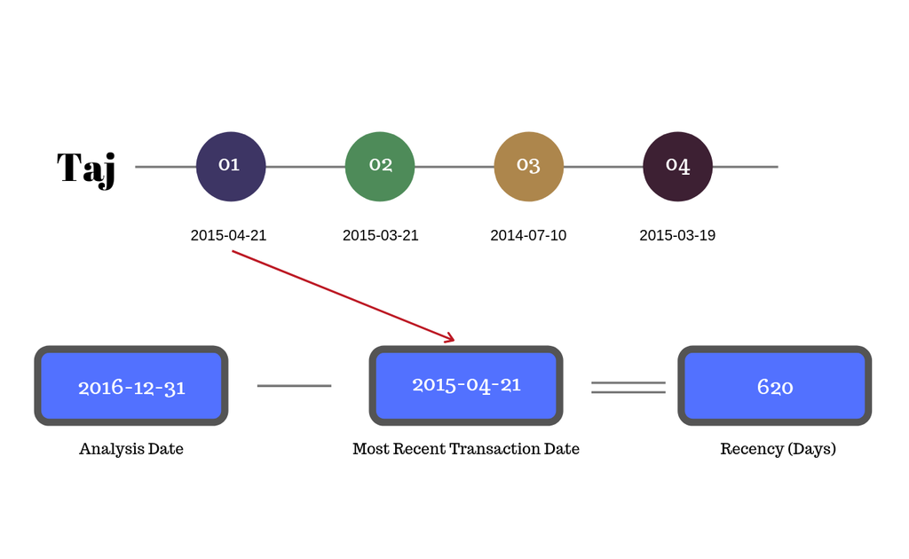

## Frequency

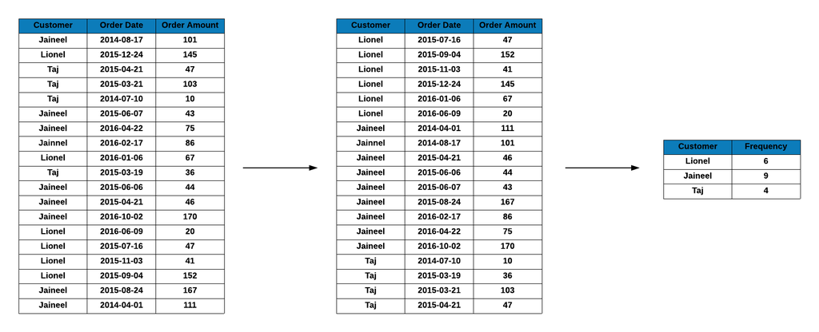

## Monetary Value

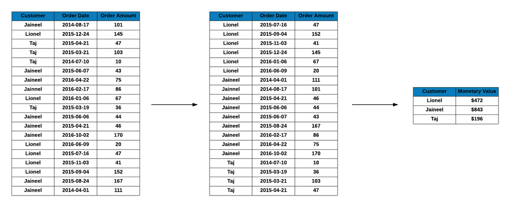

## Monetary Score

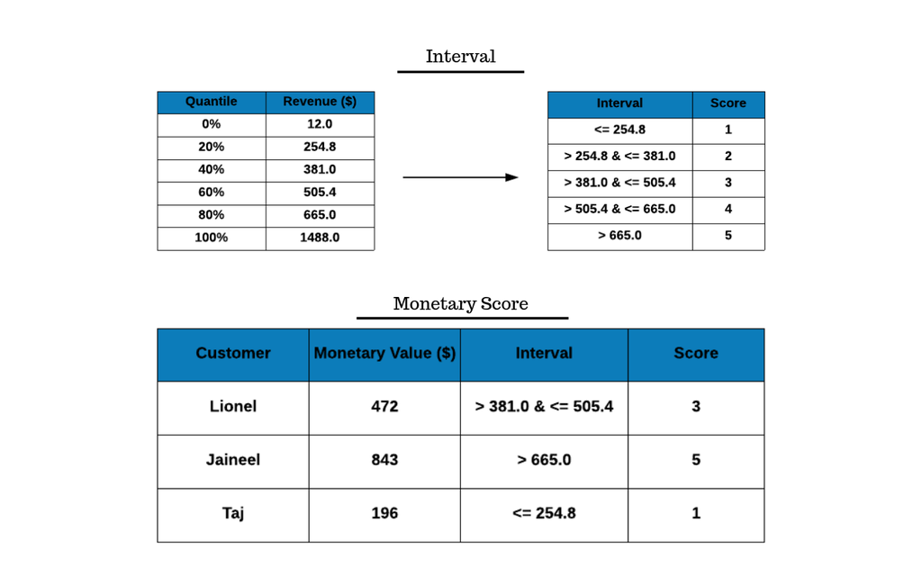

## Frequency Score

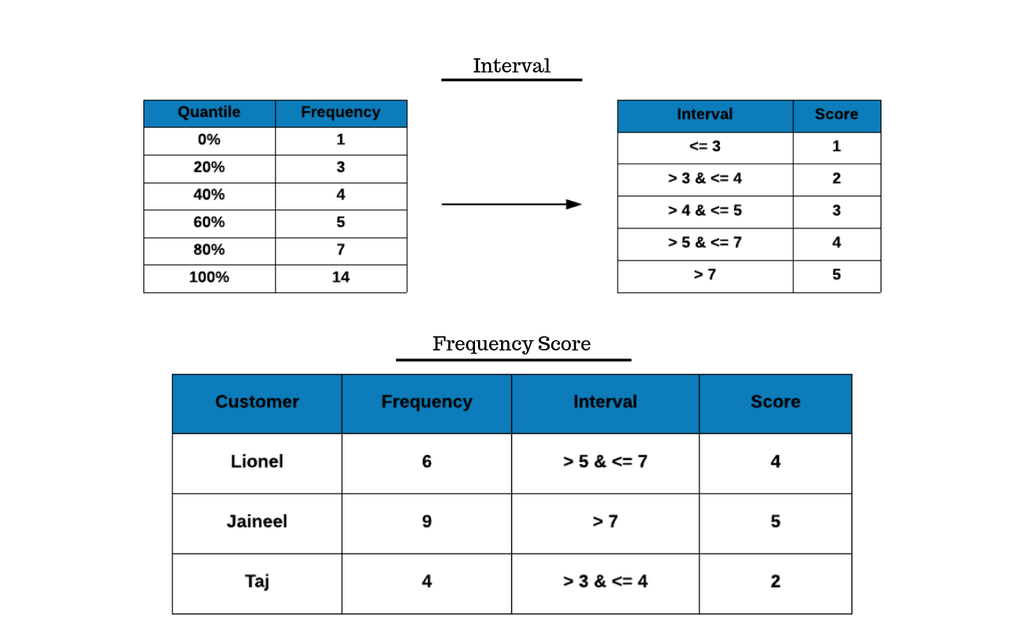

## Recency Score

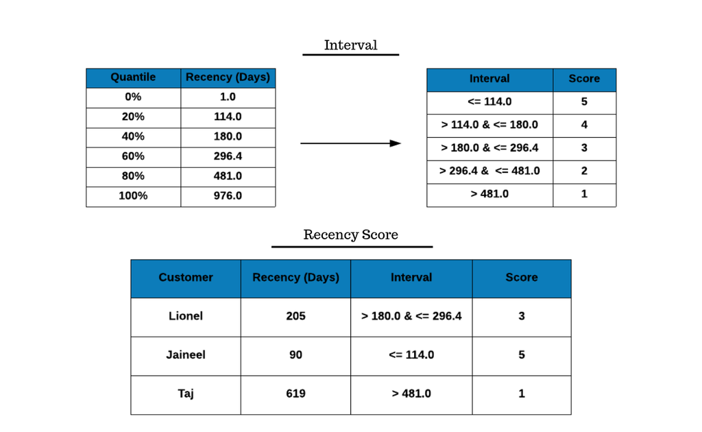

## RFM Score

RFM Score = Recency Score * 100 + Frequency Score * 10 + Monetary Score

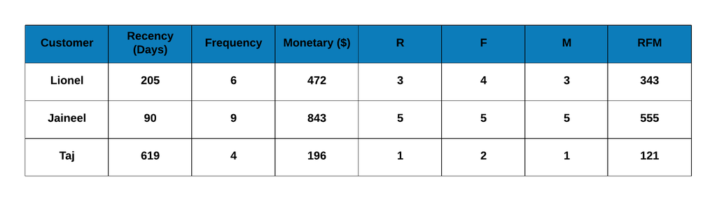

## Segments

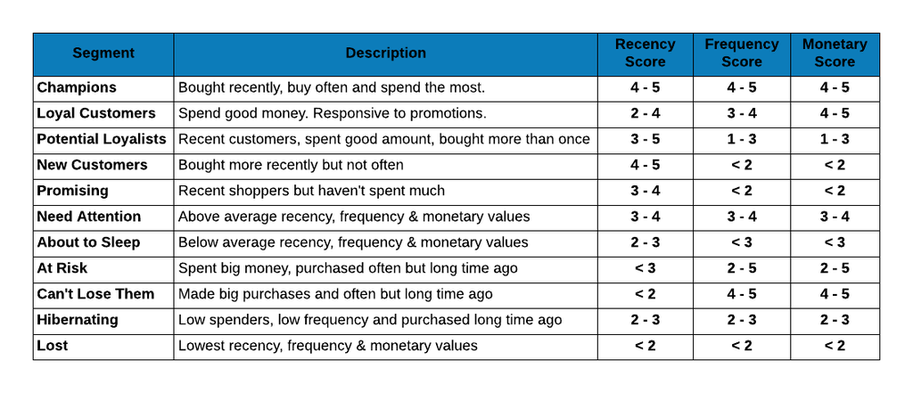

## Segments

[figure not shown]

## Segmented Customer Data

| customer_id | segment | rfm_score | transaction_count | recency_days | amount |
| --- | --- | --- | --- | --- | --- |
| Abbey O’Reilly DVM | Need Attention | 343 | 6 | 205 | 472 |
| Add Senger | Potential Loyalist | 412 | 3 | 140 | 340 |
| Aden Lesch Sr. | Hibernating | 323 | 4 | 194 | 405 |
| Admiral Senger | Need Attention | 433 | 5 | 132 | 448 |
| Agness O’Keefe | Champions | 555 | 9 | 90 | 843 |
| Aileen Barton | Champions | 555 | 9 | 84 | 763 |
| Ailene Hermann | Others | 355 | 8 | 281 | 699 |
| Aiyanna Bruen PhD | About To Sleep | 321 | 4 | 246 | 157 |
| Ala Schmidt DDS | About To Sleep | 212 | 3 | 349 | 363 |
| Alannah Borer | Others | 121 | 4 | 619 | 196 |
| Alcide Rohan | Need Attention | 433 | 5 | 138 | 500 |
| Aleena Berge | Potential Loyalist | 523 | 4 | 102 | 393 |
| Alessandra Heaney | Promising | 411 | 1 | 168 | 28 |
| Alethea Blanda | Potential Loyalist | 421 | 4 | 157 | 245 |
| Alex Armstrong | Can’t Lose Them | 144 | 6 | 482 | 634 |
| Alex Bergnaum | About To Sleep | 311 | 1 | 239 | 175 |
| Alexis Cormier | Champions | 455 | 8 | 150 | 786 |
| Alf Lueilwitz | Need Attention | 344 | 7 | 202 | 596 |
| Alferd Ziemann | Loyal Customers | 335 | 5 | 245 | 697 |
| Alfred Metz | Loyal Customers | 345 | 7 | 245 | 703 |
| Almedia Yundt | Potential Loyalist | 423 | 4 | 146 | 436 |
| Alpheus Wilkinson | At Risk | 244 | 6 | 405 | 597 |
| Alphonse Champlin V | Others | 342 | 7 | 214 | 367 |
| Alton Wintheiser | Hibernating | 233 | 5 | 475 | 392 |
| Alvah Bogisich | Others | 354 | 8 | 191 | 598 |
| Alvera Balistreri | Need Attention | 434 | 5 | 127 | 539 |
| Alwina Wilkinson DDS | Loyal Customers | 345 | 6 | 227 | 712 |
| Alyssia Hickle | Hibernating | 333 | 5 | 209 | 387 |
| Amina Renner | Need Attention | 334 | 5 | 215 | 663 |
| Amit Langworth | About To Sleep | 211 | 2 | 414 | 253 |

[output cut: 965 more lines]

## Segments

| Segment | Description | R | F | M |
| --- | --- | --- | --- | --- |
| Champions | Bought recently, buy often and spend the most | 4 - 5 | 4 - 5 | 4 - 5 |
| Loyal Customers | Spend good money. Responsive to promotions | 2 - 4 | 3 - 4 | 4 - 5 |
| Potential Loyalist | Recent customers, spent good amount, bought more than once | 3 - 5 | 1 - 3 | 1 - 3 |
| New Customers | Bought more recently, but not often | 4 - 5 | < 2 | < 2 |
| Promising | Recent shoppers, but haven’t spent much | 3 - 4 | < 2 | < 2 |
| Need Attention | Above average recency, frequency & monetary values | 3 - 4 | 3 - 4 | 3 - 4 |
| About To Sleep | Below average recency, frequency & monetary values | 2 - 3 | < 3 | < 3 |
| At Risk | Spent big money, purchased often but long time ago | < 3 | 2 - 5 | 2 - 5 |
| Can’t Lose Them | Made big purchases and often, but long time ago | < 2 | 4 - 5 | 4 - 5 |
| Hibernating | Low spenders, low frequency, purchased long time ago | 2 - 3 | 2 - 3 | 2 - 3 |
| Lost | Lowest recency, frequency & monetary scores | < 2 | < 2 | < 2 |

## Segment Size

```
## # A tibble: 12 x 2
##    Segment            Count
##    <chr>              <int>
##  1 At Risk              157
##  2 Potential Loyalist   132
##  3 Others               128
##  4 Champions            116
##  5 Need Attention       100
##  6 Hibernating           97
##  7 About To Sleep        92
##  8 Lost                  75
##  9 Loyal Customers       43
## 10 Promising             21
## 11 Can't Lose Them       17
## 12 New Customers         17
```

## Median Recency

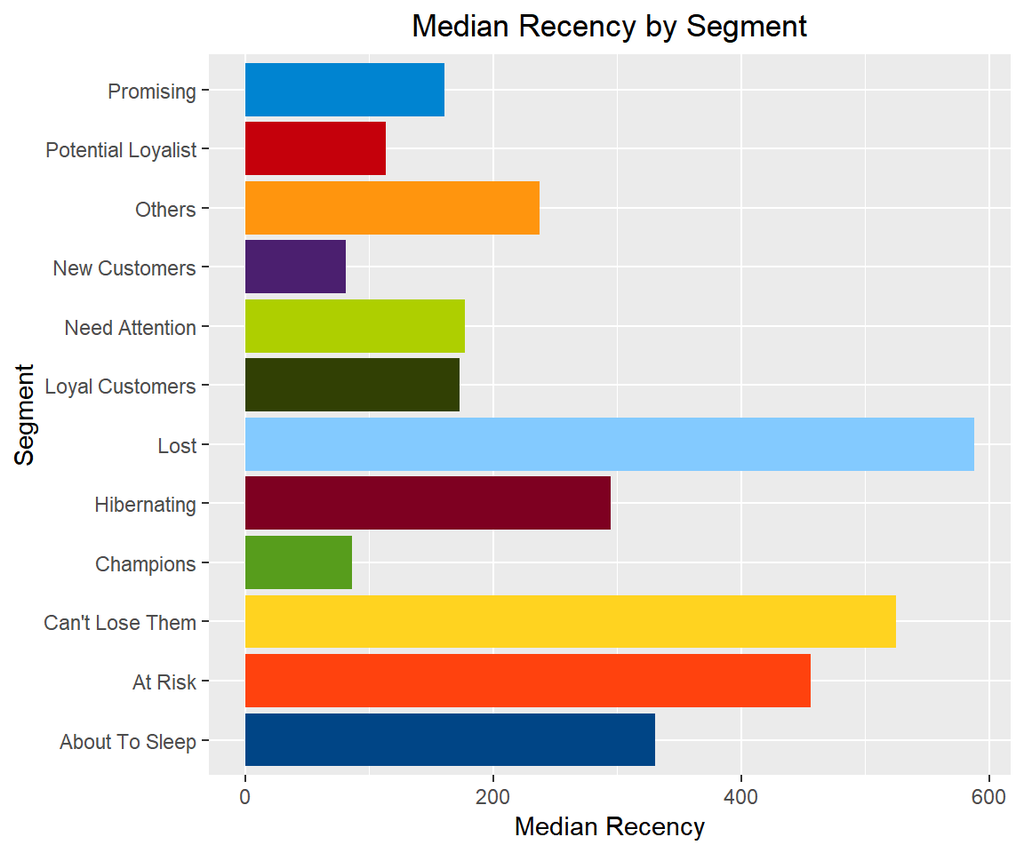

## Median Frequency

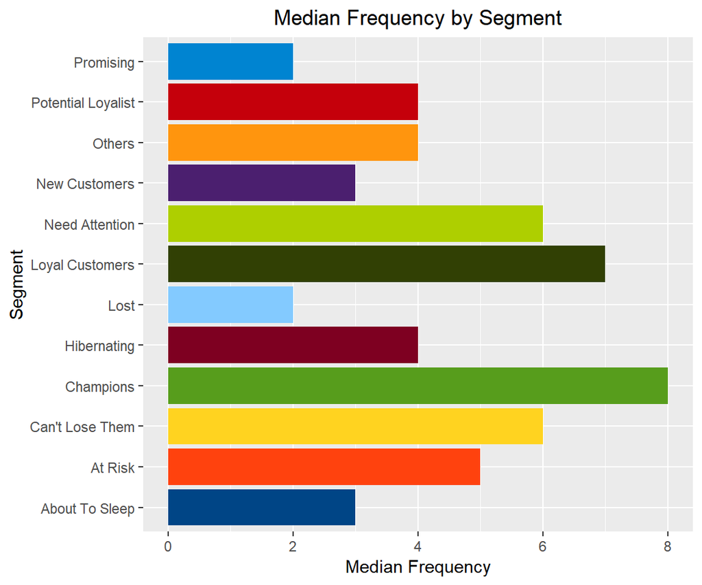

## Median Monetary Value

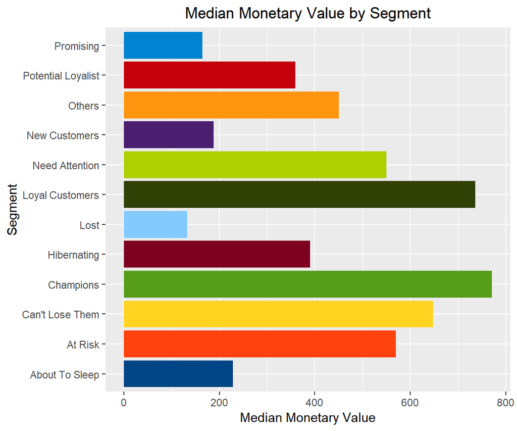

## Your Turn..

If you look at the distribution of segments, around 13% of the customers are in the `Others` segment For segmentation to be effective and optimal, the `Others` segment should be eliminated or should have few customers only. Redefine the segments and try to reduce the number of customers in the `Others` segment.

We have defined 11 segments. Try to combine some of the exisiting segments and bring down the total segments to around 6 or 8.

The RFM score we generated uses score between 1 and 5. Try to create segments by using a score between 1 and 3 i.e. the lowest RFM should be 111 and the highest should be 333 instead of 555.

Reverse the scores i.e. so far we have assigned a score of 5 to customers who visited recently, frequently and had higher transaction amount and 1 to customers who visited way back, rarely and have low transaction amount. Reverse this score pattern and create the segments.